# **Analysis of Crypto Stock Market Data**

Fall 2025 Data Science Project

Group Members: Kira Le, Alexandra White, Vinav Mehta, Gaoussou Toure

## Contributions:

Kira - Data preprocessing and feature formatting (timestamp conversion, numeric parsing), Logistic Regression setup, and assisting with final documentation and visuals.

Alexandra - Hypothesis testing and correlation analysis with visualizations, feature importance evaluation, and supporting results interpretation and conclusion writing.

Vinav - Project direction and ML pipeline development, creation of the 24-hour future price target labeling, train/test split based on timestamps, and Random Forest model implementation. Assisted with the writing of the introdcution as well as conclusion.

Gaoussou - Exploratory data analysis summary statistics and initial visualizations, confusion matrix + ROC curve creation, and writing insights on model interpretation.

# Introduction

The overall objective of this project will be to analyze crypto currency in the stock market from March 2025 to present day. We hope to answer our primary question in order to help people make money!

Cryptocurrency markets have been defined by high volatility, rapid price swings, and inconsistent signals about long term sustainability. Since their inception, cryptocurrency markets have been extremely difficult to predict. For individual investors, this creates a challenging environment: while large gains are possible, so are large and rapid losses, and distinguishing meaningful trends from meaningless market noise is difficult for any human. To investigate whether short-term market data can guide investment decisions, we analyze a cryptocurrency dataset from Kaggle’s Crypto and Stock Market Data dataset, which provides detailed information on various metrics that we will attempt to use to predict the movement of cryptocurrencies.

The central question motivating our project is: *Can we predict whether a cryptocurrency will experience a positive or negative price change in the next 24 hours using recent market indicators?*

If such predictions are even moderately reliable, they could help investors decide whether a given cryptocurrency is worth entering, avoiding, or monitoring more closely. Conversely, if the models fail to outperform random guessing, that result would indicate that short-term crypto movements are effectively unpredictable for practical investment purposes, and that investors should not attemt to find trends when they do not exist, and can use other criteria to inform their investing strategies.

This question is important because it tests a common assumption in the crypto community. This assumption is that past momentum, trading volume, or market cap trends can signal short term gains or losses. By cleaning and structuring the dataset, performing exploratory analysis and hypothesis testing, and training machine learning models on recent market features, we aim to evaluate whether these indicators contain actionable information for decision making or amount to little more than just noise. Our analysis ultimately seeks to give readers a clearer understanding of how predictable (or unpredictable) short term crypto performance truly is,, and whether or not data science can help inform our investing choices.

**Required Tools**

You will need the following libraries for this project:

1. pandas
2. numpys
3. matplotlib
4. Kagglehub
5. Seaborn
6. numpy
7. scipy
8. sklearn

## Data Curation

The first part of this project in the data science life cycle is data collection. We decided to use a data set from kaggle that was recent, updated daily, and scored a 10 on usability. These criterias were important to us because we wanted to make sure we have relevant data to ensure that our analysis is accurate and can yield the best advice for our viewers.

Selected df: https://www.kaggle.com/datasets/adrianjuliusaluoch/crypto-and-stock-market-data-for-financial-analysis

The kaggle data set is organized by data and timestamp, crypto name, crypto symbol, price in USD, 24 hour trade volume, total market volume, 24 hour and 7 day price change in %, and market captialization. In this section we import the data set as our own data frame in order to manipulate, parse, and organize the data.

Below, we will take you through the steps we used to import the data set and make it a data frame, df.

```python
import pandas as pd
import kagglehub
import matplotlib.pyplot as plt
import matplotlib.ticker as mtick
import seaborn as sns
import numpy as np
from sklearn.preprocessing import StandardScaler
from sklearn.linear_model import LogisticRegression
from sklearn.ensemble import RandomForestClassifier
from sklearn.metrics import accuracy_score, classification_report, confusion_matrix, ConfusionMatrixDisplay, roc_curve, auc
from scipy import stats

path = kagglehub.dataset_download("adrianjuliusaluoch/crypto-and-stock-market-data-for-financial-analysis")
df = pd.read_csv(path + '/cryptocurrency.csv')
df.head()
```

```
Downloading from https://www.kaggle.com/api/v1/datasets/download/adrianjuliusaluoch/crypto-and-stock-market-data-for-financial-analysis?dataset_version_number=114...
```

```
Extracting files...
```

|  | timestamp | name | symbol | price_usd | vol_24h | total_vol | chg_24h | chg_7d | market_cap |
| --- | --- | --- | --- | --- | --- | --- | --- | --- | --- |
| 0 | 2025-12-08 22:53:02 | LEO Token | leo | $9.75 | $513,934.00 | 0.00% | +1.65% | -0.73% | $8,986,279,553 |
| 1 | 2025-12-08 22:53:02 | Figure Heloc | figr_heloc | $1.03 | $9,018,865.00 | 0.01% | +1.44% | +0.22% | $14,549,145,964 |
| 2 | 2025-12-08 22:53:02 | Wrapped Beacon ETH | wbeth | $3,389.37 | $12,185,659.00 | 0.01% | -0.43% | +14.16% | $11,043,482,670 |
| 3 | 2025-12-08 22:53:02 | Wrapped eETH | weeth | $3,381.62 | $21,795,487.00 | 0.01% | -0.46% | +13.83% | $7,969,687,578 |
| 4 | 2025-12-08 22:53:02 | sUSDS | susds | $1.08 | $14,757,970.00 | 0.01% | -0.04% | +0.06% | $4,212,256,112 |

```python
print('Shape of df:', df.shape)
print('Data Types in df:\n')
df.dtypes
```

```
Shape of df: (48550, 9)
Data Types in df:
```

|  | 0 |
| --- | --- |
| timestamp | object |
| name | object |
| symbol | object |
| price_usd | object |
| vol_24h | object |
| total_vol | object |
| chg_24h | object |
| chg_7d | object |
| market_cap | object |

**dtype:** object

**Data Processing**

Next, we will need to parse through the data in order to make conversions that will be necesssary to analyze our data. First we need to convert the string timestamp object into the timestamp type. Next we need to convert dollars to float, as some of the data points contain T, B, M, and K indicating the number is represented in the trillions, billions, millions, or thousands respectively. Additionally, we convert percentages to floats by dividing by 100. We apply these changes to our df to create the cleaned_df

```python
def dollars_to_float(series: pd.Series) -> pd.Series:
    s = series.astype(str)
    s = s.mask(s.str.contains('%', na=False))
    s = s.str.replace(r'[\$,]', '', regex=True)
    s = s.str.replace(r'([0-9\.]+)T', lambda m: str(float(m.group(1)) * 1_000_000_000_000), regex=True)
    s = s.str.replace(r'([0-9\.]+)B', lambda m: str(float(m.group(1)) * 1_000_000_000), regex=True)
    s = s.str.replace(r'([0-9\.]+)M', lambda m: str(float(m.group(1)) * 1_000_000), regex=True)
    s = s.str.replace(r'([0-9\.]+)K', lambda m: str(float(m.group(1)) * 1_000), regex=True)
    return s.astype(float)
def percent_to_float(series: pd.Series) -> pd.Series:
    s = series.astype(str)
    s = s.mask(s.str.contains(r'\$', na=False))
    s = s.str.replace('%', '', regex=True)
    s = s.astype(float) / 100
    return s
cleaned_df = df.copy()
cleaned_df['timestamp'] = pd.to_datetime(df['timestamp'])
cleaned_df['price_usd'] = dollars_to_float(df['price_usd'])
cleaned_df['vol_24h'] = dollars_to_float(df['vol_24h'])
cleaned_df['total_vol'] = percent_to_float(df['total_vol'])
cleaned_df['chg_24h'] = percent_to_float(df['chg_24h'])
cleaned_df['chg_7d'] = percent_to_float(df['chg_7d'])
cleaned_df['market_cap'] = dollars_to_float(df['market_cap'])
cleaned_df.head()
```

|  | timestamp | name | symbol | price_usd | vol_24h | total_vol | chg_24h | chg_7d | market_cap |
| --- | --- | --- | --- | --- | --- | --- | --- | --- | --- |
| 0 | 2025-12-08 22:53:02 | LEO Token | leo | 9.75 | 513934.0 | 0.0000 | 0.0165 | -0.0073 | 8.986280e+09 |
| 1 | 2025-12-08 22:53:02 | Figure Heloc | figr_heloc | 1.03 | 9018865.0 | 0.0001 | 0.0144 | 0.0022 | 1.454915e+10 |
| 2 | 2025-12-08 22:53:02 | Wrapped Beacon ETH | wbeth | 3389.37 | 12185659.0 | 0.0001 | -0.0043 | 0.1416 | 1.104348e+10 |
| 3 | 2025-12-08 22:53:02 | Wrapped eETH | weeth | 3381.62 | 21795487.0 | 0.0001 | -0.0046 | 0.1383 | 7.969688e+09 |
| 4 | 2025-12-08 22:53:02 | sUSDS | susds | 1.08 | 14757970.0 | 0.0001 | -0.0004 | 0.0006 | 4.212256e+09 |

Lastly in this step, we changed 24 hour trade volume and market capitalization to be represented in the millions of $ for sake of reading simplicity. After these curation steps, we have displayed the head of the final cleaned data.

```python
cleaned_df['vol_24h_millions_$'] = cleaned_df['vol_24h'] / 1_000_000
cleaned_df['market_cap_millions_$'] = cleaned_df['market_cap'] / 1_000_000
cleaned_df.drop(['vol_24h', 'market_cap'], axis=1, inplace=True)
cleaned_df.head()
```

|  | timestamp | name | symbol | price_usd | total_vol | chg_24h | chg_7d | vol_24h_millions_$ | market_cap_millions_$ |
| --- | --- | --- | --- | --- | --- | --- | --- | --- | --- |
| 0 | 2025-12-08 22:53:02 | LEO Token | leo | 9.75 | 0.0000 | 0.0165 | -0.0073 | 0.513934 | 8986.279553 |
| 1 | 2025-12-08 22:53:02 | Figure Heloc | figr_heloc | 1.03 | 0.0001 | 0.0144 | 0.0022 | 9.018865 | 14549.145964 |
| 2 | 2025-12-08 22:53:02 | Wrapped Beacon ETH | wbeth | 3389.37 | 0.0001 | -0.0043 | 0.1416 | 12.185659 | 11043.482670 |
| 3 | 2025-12-08 22:53:02 | Wrapped eETH | weeth | 3381.62 | 0.0001 | -0.0046 | 0.1383 | 21.795487 | 7969.687578 |
| 4 | 2025-12-08 22:53:02 | sUSDS | susds | 1.08 | 0.0001 | -0.0004 | 0.0006 | 14.757970 | 4212.256112 |

# Exploratory Data Analysis

In this section of our tutorial, we will be going through three different statistical methods in order to explore different aspects of the data set.

**Method 1**

The first method calculates key summary statistics (mean, median, and mode) for crypto currency prices in USD. It then visualizes the full price distribution using a histogram with logarithmic scaling, percentage-based heights, and a KDE curve for smoother density estimation.

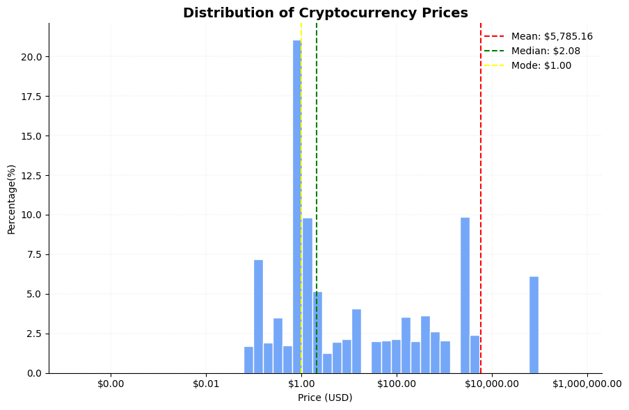

```python
# Calculate summary stats
mean_price = cleaned_df['price_usd'].mean()
median_price = cleaned_df['price_usd'].median()
mode_price = cleaned_df['price_usd'].mode()[0]

# Create figure
plt.figure(figsize=(9,6))
sns.histplot(
    cleaned_df['price_usd'],
    bins=30,
    log_scale=True,
    stat='percent',
    kde=True,
    color="#3b82f6",
    alpha=0.7,
    edgecolor="white"
)

# Add vertical summary lines
plt.axvline(mean_price, color='red', linestyle='--', label=f"Mean: ${mean_price:,.2f}")
plt.axvline(median_price, color='green', linestyle='--', label=f"Median: ${median_price:,.2f}")
plt.axvline(mode_price, color='yellow', linestyle='--', label=f"Mode: ${mode_price:,.2f}")

# Title and labels
plt.title("Distribution of Cryptocurrency Prices", fontsize=14, weight='bold')
plt.xlabel("Price (USD)")
plt.ylabel("Percentage(%)")

# Dollar formatting on x-axis
plt.gca().xaxis.set_major_formatter(mtick.StrMethodFormatter('${x:,.2f}'))

plt.legend(frameon=False, loc='upper right')
plt.grid(True, which="both", ls="--", lw=0.3, alpha=0.4)
sns.despine(top=True, right=True)
plt.tight_layout()
plt.xlim(0.000005, 2_000_000)
plt.show()
```

**Method 2**

In the second method, we are testing if there is a statistical significant relationship between 24 hour price change and 7 day price change among cryptocurrencies. After removing missing values, it computes the Pearson correlation coefficient and corresponding p-value to measure both the strength and significance of the linear relationship.The results are printed, and a regression plot is generated to visualize the relationship, showing individual data points along with a best-fit line.

```
Correlation coefficient (r): 0.329033
P-value: 0.000000
```

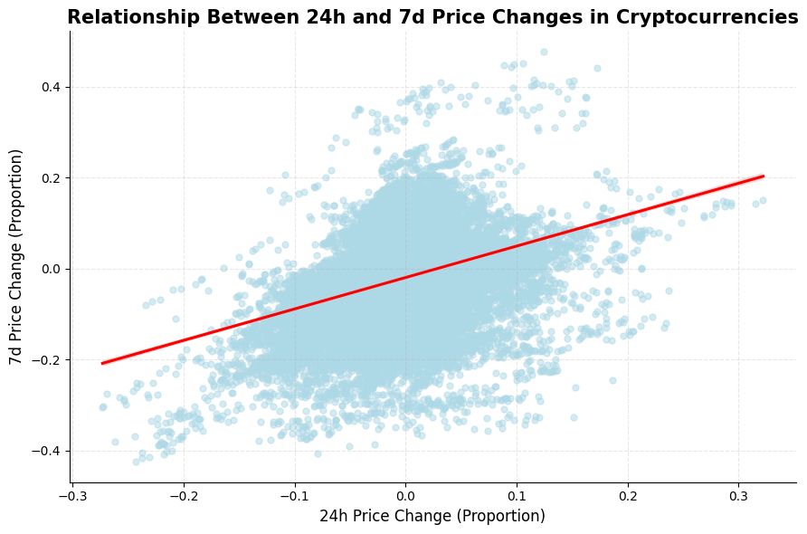

```python
# Hypothesis Test: Is there a statistically significant relationship between daily price change (chg_24h)
#                   and weekly price change (chg_7d) among cryptocurrencies

daily_weekly_df = cleaned_df[['chg_24h', 'chg_7d']].dropna()

# Pearson correlation test
corr_coef, p_value = stats.pearsonr(daily_weekly_df['chg_24h'], daily_weekly_df['chg_7d'])

print(f"Correlation coefficient (r): {corr_coef:4f}")
print(f"P-value: {p_value:.6f}")

# Displaying
plt.figure(figsize=(9,6))
sns.regplot(
    x = 'chg_24h',
    y = 'chg_7d',
    data = daily_weekly_df,
    scatter_kws = {'alpha': 0.5, 's':25, 'color':'lightblue'},
    line_kws = {'color':'red'}
)

plt.title("Relationship Between 24h and 7d Price Changes in Cryptocurrencies", fontsize=15, weight='bold')
plt.xlabel("24h Price Change (Proportion)", fontsize=12)
plt.ylabel("7d Price Change (Proportion)", fontsize=12)
plt.grid(alpha=0.3, linestyle='--')
sns.despine()
plt.tight_layout()
plt.show()
```

Null Hypothesis: There is no correlation between 24-hour and 7-day price changes

Alternative Hypothesis: There is a correlation between 24-hour and 7-day price changes

**Method 3**

In our last method, we explore the correlation between market capitalization in millions of dollars and trade 24 hour trade volume in millions of dollars. After filtering out missing values, it performs a Pearson correlation test to compute both the correlation coefficient and the p-value, indicating the strength and statistical significance of the relationship. The data is then visualized using a scatter plot with logarithmic scaling on both axes to accommodate the wide range of values.

```
Correlation coefficient: 0.6177
P-value: 0.0000
```

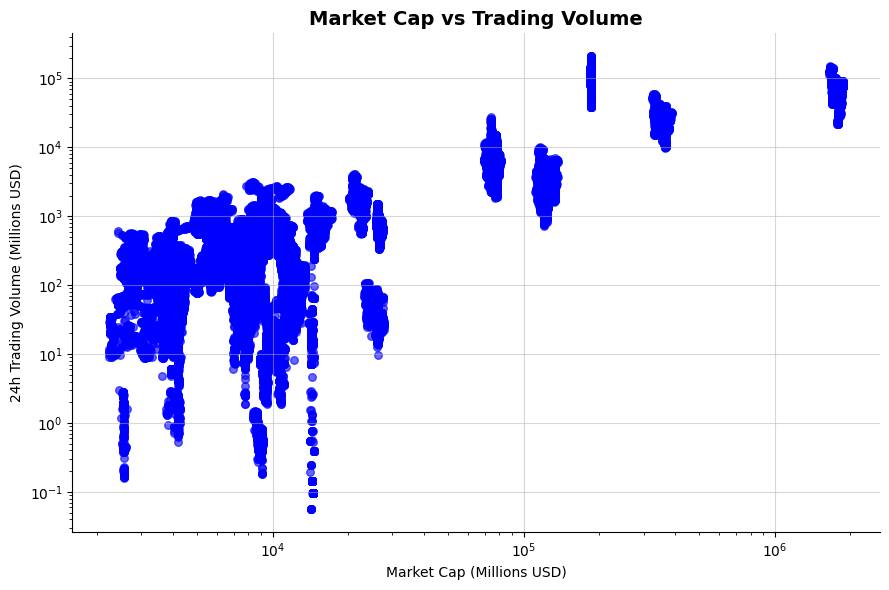

```python
# Hypothesis Test: Correlation between Market Cap and Trading Volume

test_df = cleaned_df[['market_cap_millions_$', 'vol_24h_millions_$']].dropna()
corr_coef, p_value = stats.pearsonr(test_df['market_cap_millions_$'], test_df['vol_24h_millions_$'])
print(f"Correlation coefficient: {corr_coef:.4f}")
print(f"P-value: {p_value:.4f}")
plt.figure(figsize=(9,6))
plt.scatter(
    test_df['market_cap_millions_$'],
    test_df['vol_24h_millions_$'],
    alpha=0.6,
    color="blue",
    s=30
)

plt.xscale('log')
plt.yscale('log')
plt.xlabel('Market Cap (Millions USD)')
plt.ylabel('24h Trading Volume (Millions USD)')
plt.title('Market Cap vs Trading Volume', fontsize=14, weight='bold')
plt.grid(True, alpha=0.5)
sns.despine(top=True, right=True)
plt.tight_layout()
plt.show()
```

**Conclusion #3**

In this hypothesis test, we conducted a correlation hypothesis test to examine the relationship between market capitalization and 24-hour trading volume.

The null hypothesis (H₀) stated that there is no correlation between market cap and 24-hour trading volume. The alternative hypothesis (H₁) stated that there is a correlation between the two variables.

The results produced a p-value less than 0.001, which is below the chosen significance level of 0.05 (α = 0.05). Therefore, we reject the null hypothesis and conclude that there is a moderate positive linear relationship between market cap and 24-hour trading volume.

# Primary Analysis

The raw dataset contains snapshots of many cryptocurrencies at irregular intervals (approximately every 10–30 minutes), with fields such as `price_usd`, `chg_24h`, and `chg_7d`. However, these percentage changes tells us information about the past. They describe how much the price has moved in the last 24 hours or 7 days and tell us nothing about the future. In order to create a machine learning algorithm to predict future cryptocurrency prices, we need to introduce future looking data. To do this, we will create a new column in our dataframe which will tell us what the price of the cryuptocurrency ended up being roughly 24 hours after the datum was collected.

Here, we now need to create a df to hold all of our data, with current market indicators as well as what the price ended up being 24 hours later. This will help us create a machine learning model that can use past example of market facts and prices along with their future prices in order to predict future prices with current market indicators. We begin by create a dataframe that contains the price of each row, as close to 24 hours in the future as possible. We will then merge that dataframe with the cleaned_df in order to create a new binary column, with 0s and 1s, to represent whether or not the price went up or down 24 hours later. 0 represents that the price did not go up, while 1 represents that the price did indeed go up.

```python
# let us first begin by creating a copy of the cleaned_df that we can use for our machine learning model
ml_df = cleaned_df.copy()
# lets also look at the types of the dataframe
ml_df.dtypes
```

|  | 0 |
| --- | --- |
| timestamp | datetime64[ns] |
| name | object |
| symbol | object |
| price_usd | float64 |
| total_vol | float64 |
| chg_24h | float64 |
| chg_7d | float64 |
| vol_24h_millions_$ | float64 |
| market_cap_millions_$ | float64 |

**dtype:** object

After this we will need to use the timestamp values in order to find the future price 24 hours into the future. To ensure consistency, let's make sure that the timestamp is in the proper datetime format

```python
ml_df['timestamp'] = pd.to_datetime(ml_df['timestamp'])
```

Here, we will now calculate the timestamp for the datum that is 24 hours into the future. We will match this data up in pairs so that every piece of data has an additional column which tells us whether or not the future price ended up going up or down.

```python
# sort by coin name then the time
ml_df = ml_df.sort_values(['name', 'timestamp'])

# find the timestamp that would be 24 hours later
ml_df['timestamp_24h'] = ml_df['timestamp'] + pd.Timedelta(hours=24)

# here we are creating a new df that has the information about the data in 24 hours
future_df = ml_df[['name', 'timestamp', 'price_usd']].rename(columns={'timestamp': 'timestamp_future', 'price_usd': 'price_usd_24h'})

# we use merge_asof() in order to align each row with the first timestamp that is 24 hours into the future of the current row's timestamp
df_merged = pd.merge_asof(ml_df.sort_values('timestamp_24h'),future_df.sort_values('timestamp_future'),by='name',left_on='timestamp_24h',right_on='timestamp_future',direction='forward')

# we need to drop any rows that do not have a corresponding row 24 hours into the future
df_merged = df_merged.dropna(subset=['price_usd_24h'])

# we calculate the flag that tells us if the future price went up (1) or did not (0). This is a binary label that will help us trian our machine learning model
df_merged['target_up_24h'] = (df_merged['price_usd_24h'] > df_merged['price_usd']).astype(int)
```

Before we move on to the actual creation of the machine learning model, let us take a look at the dsitribution of the class, or flag. What this means is that we are going to look at what percent of the times the future (24 hour in the future price) ends up being a 0 (same or lower) or a 1 (higher price). This will tell us if there is an imbalance in the label. When there are imbalances that are not accounted for, the machine learning model that we create can have a bias towards the more common flag rather than actually using the data that we want it to make the decisions off of. This can lead to issues where test data that does not share the same imbalance as the training data causes the model to perform very poorly.

```
Class counts (0 = down/flat, 1 = up):
target_up_24h
0    30517
1    15500
Name: count, dtype: int64

Class proportions:
target_up_24h
0    0.663168
1    0.336832
Name: proportion, dtype: float64
```

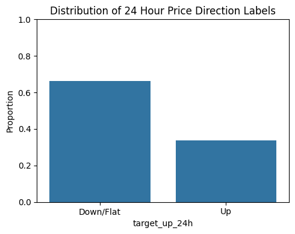

```python
label_counts = df_merged['target_up_24h'].value_counts().sort_index()
label_props = df_merged['target_up_24h'].value_counts(normalize=True).sort_index()

print("Class counts (0 = down/flat, 1 = up):")
print(label_counts)
print("\nClass proportions:")
print(label_props)

# let us now create a plot with this information
plt.figure(figsize=(5, 4))
sns.barplot(x=label_props.index.map({0: 'Down/Flat', 1: 'Up'}), y=label_props.values)
plt.ylabel("Proportion")
plt.title("Distribution of 24 Hour Price Direction Labels")
plt.ylim(0, 1)
plt.tight_layout()
plt.show()
```

Here in the price direction flag we see that there is significantly more down or flat cases than cases where the cryptocurrency price actually increases. This holds with real world data since it has been noted that downticks in the market are more common with cryptocurrency as downticks are more marginal, while upticks in price as more sudden and large. This means that more days may be downwards in terms of price than increases, but the price is still trending upwards in the long term. This also informs our decisions about the machine learning modeling that we want to do. Using class_weight = balanced in the Random Forest model can help us offset this skewness and create more accurate data.

```python
# Here we determine the features that we want to use in our machine learning model(s). We are choosing to use all of the available data for now. This is becasue we have seen with the preliminary analysis that all of this
# data is correlated for the most part and we want to have our models be as accurate as possible. We can see the feature importance later with the Random Forest model and then determine if there is a feature that is not
# helpful that may be confusing the model and leading to worse predictions than if that feature was not used.
feature_cols = [
    'price_usd',
    'total_vol',
    'chg_24h',
    'chg_7d',
    'vol_24h_millions_$',
    'market_cap_millions_$'
]

# Dropping rows with missing feature or label values so that we do not have data missing features and leading to unexpected bias
model_df = df_merged.dropna(subset=feature_cols + ['target_up_24h']).copy()

X = model_df[feature_cols]
y = model_df['target_up_24h']

# Here we are sorting by time. This is because we want the training data to precede the test data. This is because we are attempting to predict the future prices using past data. This means that to create the most accurate predictions, we need to honor this temporal requirement.
model_df = model_df.sort_values('timestamp')
X = model_df[feature_cols]
y = model_df['target_up_24h']

# 80% to 20% training to test data split. This is a typical split that we have used previously in the class
split_idx = int(len(model_df) * 0.8)

X_train = X.iloc[:split_idx]
X_test  = X.iloc[split_idx:]
y_train = y.iloc[:split_idx]
y_test  = y.iloc[split_idx:]

print("Training size:", len(X_train))
print("Test size:", len(X_test))

print("\nTraining label distribution:")
print(y_train.value_counts(normalize=True).sort_index())
print("\nTest label distribution:")
print(y_test.value_counts(normalize=True).sort_index())
```

```
Training size: 36786
Test size: 9197

Training label distribution:
target_up_24h
0    0.656527
1    0.343473
Name: proportion, dtype: float64

Test label distribution:
target_up_24h
0    0.692182
1    0.307818
Name: proportion, dtype: float64
```

**Machine Learning Model Training**

For our question, we have created a binary flag. This flag, either a 0 or 1, tells us whether the price of the cryptocurrency did or did not end up going up 24 hours later.

We decided to use Random Forest as our machine learning model. Random Forest, unlike Logistic Regression, does not use a linear baseline. This allows us to capture non-linear interactions between variables. This can help us combine the features to create accurate predictions. Despite this, we will also create a logistic regression classifier so that we can compare the results of the two models, and then create some graphs to capture the results and understand the models.

We will compare the accuracy of these two machine learning models in order to determine which one is more accurate than the other, and then figure out which one would be better. This will help us understand how the features that we have selected really work together to potentially predict future cryptocurrency prices.

```python
# Here we are standardizing features for the logistic regression model.
scaler = StandardScaler()
X_train_scaled = scaler.fit_transform(X_train)
X_test_scaled = scaler.transform(X_test)

# Let us now perform logistic regression
log_reg = LogisticRegression(max_iter=10000)
log_reg.fit(X_train_scaled, y_train)
```

```
LogisticRegression(max_iter=10000)
```

Now that we have performed logistic regression, let us look at the results of the machine learning model.

```python
y_pred_log = log_reg.predict(X_test_scaled)
print("LogReg Accuracy:", accuracy_score(y_test, y_pred_log))
```

```
LogReg Accuracy: 0.688050451234098
```

Now that we have created a logistic regression model, let us move on to creating a random forest machine learning model.

```python
# let us now create a random forest machine learning model. As we mentioned earlier, we are using class_weight = balanced in order to account for the imbalanced 0s and 1s.
rf = RandomForestClassifier(n_estimators=500,random_state=42, class_weight='balanced')
rf.fit(X_train, y_train)
```

```
RandomForestClassifier(class_weight='balanced', n_estimators=500,
                       random_state=42)
```

Now that we have created a random forest model, let us look at the results of the machine learning model.

```python
y_pred_rf  = rf.predict(X_test)
print("RF Accuracy:", accuracy_score(y_test, y_pred_rf))
```

```
RF Accuracy: 0.6926171577688377
```

Looking at the accuracy of the RF model and the LR model, we see that they performed extremely similary.

Logistic Regression had an accuracy of 68.8%

Random Forest had an accuracy of 69.3%

Looking at the accuracy numbers, we can see that Random Forest is the better machine learning model for this situation. Now that we have shown that, let us dive deeper into some of the details of the Random Forest model and understand it a bit better.

Random Forest also gives us some other ways than just accuracy to see how the model performed. Let's begin by looking at the classification report.

```python
print("\nRandom Forest Classification Report:")
print(classification_report(y_test, y_pred_rf))
```

```
Random Forest Classification Report:
              precision    recall  f1-score   support

           0       0.77      0.80      0.78      6366
           1       0.50      0.45      0.47      2831

    accuracy                           0.69      9197
   macro avg       0.63      0.63      0.63      9197
weighted avg       0.68      0.69      0.69      9197
```

Looking at the above classification report, we can see that the RF model was much more accurate at predicting when the price of a cryptocurrency went down or was level 24 hours later, rather than when it went up. This makes sense because there was far more data in the training data that had the price go down 24 hours later which means that the model could become more accurate. Perhaps with much larger training sets we could imrpove both 0 and 1 accuracy from what we have currently.

Now, let us create a confusion matrix. This matrix will visualize the model's predictions in terms of up or down, versus the actuality of whether or not it ended up being up or down. This can help us evaluate the model's performance.

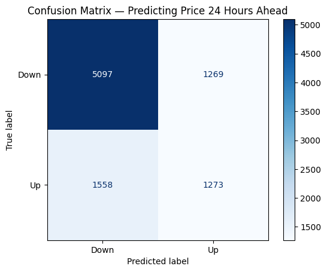

```python
cm = confusion_matrix(y_test, y_pred_rf)
disp = ConfusionMatrixDisplay(cm, display_labels=['Down', 'Up'])
disp.plot(cmap='Blues')
plt.title("Confusion Matrix — Predicting Price 24 Hours Ahead")
plt.show()
```

Looking at the above confusion matrix, we can see that the model had a significant asymmetry between predicting upticks and downticks in the market. This pattern again reflects the imbalance in the training data. Downward trends also appear to be more systematic and thus easier to infer from market indicators that we used as features. Upwards trends were much harder to capture with the features we had available through our chosen dataset.

Finally, let us look at the importance of each feature that we used to train the random forest machine learning model.

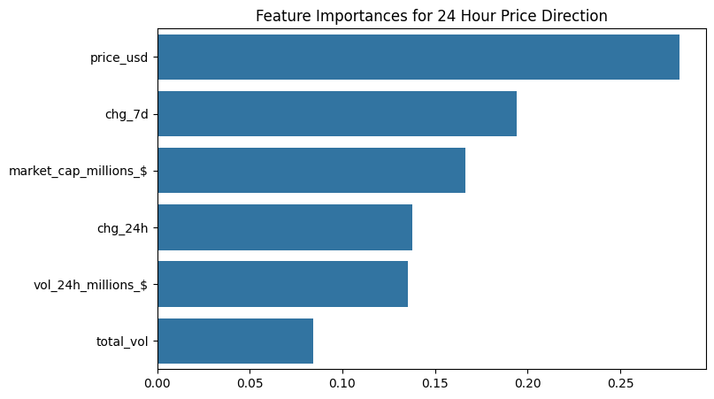

```python
importances = rf.feature_importances_
indices = importances.argsort()[::-1]
plt.figure(figsize=(8,5))
sns.barplot(x=importances[indices],y=np.array(feature_cols)[indices])
plt.title("Feature Importances for 24 Hour Price Direction")
plt.show()
```

Looking at the feature importance graph pictured above, we can see what features were most impactful in the training of our RF model. Clearly, the most impactful feature was the current price, followed by the 7 day change. These two factors informed the model's prediction the most. Something that we found surprising was that the 24 hour change was all the way down at fourth. We expected it to be right next to 7 day change, and perhaps even higher. We though that 24 hour momentum would be statistcally significant in determining weekly changes, but that was not the case.

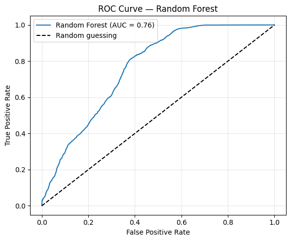

```python
y_proba_rf = rf.predict_proba(X_test)[:, 1]

fpr, tpr, thresholds = roc_curve(y_test, y_proba_rf)
roc_auc = auc(fpr, tpr)

plt.figure(figsize=(6, 5))
plt.plot(fpr, tpr, label=f"Random Forest (AUC = {roc_auc:.2f})")
plt.plot([0, 1], [0, 1], 'k--', label="Random guessing")
plt.xlabel("False Positive Rate")
plt.ylabel("True Positive Rate")
plt.title("ROC Curve — Random Forest")
plt.legend()
plt.grid(alpha=0.3)
plt.tight_layout()
plt.show()
```

In this case, it tells us that the model assigns a higher probability to a true up case than a true down case about 76% of the time. This means that the model is predicting which data points are likely to experience price increases at a rate much higher than randomly guessing, as we can see in the plot.

# Insights and Conclusion

In terms of feature importance, the Random Forest model often assigns relatively high importance to:

- **Current price and weekly price change**, which distinguish large, more stable coins from smaller, more volatile ones.
- **Short-term changes** (`chg_24h`), which encodes recent momentum swings is moderately effective at predicting cyrptocurrency price changes 24 hours in the future.

# References and Additional Resources

Tools to help you predict or understand cryptocurrency prices and trends

1. https://naga.com/en/academy/cryptocurrency-price-predictions
2. https://www.sciencedirect.com/science/article/pii/S1057521923005719
3. https://pmc.ncbi.nlm.nih.gov/articles/PMC7256561/

Understanding Machine Learning Models

1. https://www.datacamp.com/blog/machine-learning-models-explained
2. https://www.ibm.com/think/topics/logistic-regression
3. https://www.ibm.com/think/topics/random-forest